# Food Consumption

Aidan Boland

4/6/2020

## Easy load

A pre-cleaned version of the data can be loaded using the following command.

```r
food_consumption <- readr::read_csv('https://raw.githubusercontent.com/rfordatascience/tidytuesday/master/data/2020/2020-02-18/food_consumption.csv')
```

## Raw Data Load and Clean

The following section shows how the code can be read from the following site nu3.de/blogs/nutrition/food-carbon-footprint-index-2018

```r
library(tidyverse)
library(janitor)
library(rvest)

# Credit to Kasia and minorly edited to create output file and test plot
# Blog post at https://r-tastic.co.uk/post/from-messy-to-tidy/

url <- "https://www.nu3.de/blogs/nutrition/food-carbon-footprint-index-2018"

# scrape the website
url_html <- read_html(url)

# extract the HTML table
whole_table <- url_html %>%
  html_nodes('table') %>%
  html_table(fill = TRUE) %>%
  .[[1]]

head(whole_table) %>%
  kable()
```

| X1 | X2 | X3 | X4 | X5 | X6 | X7 | X8 | X9 | X10 | X11 | X12 | X13 | X14 | X15 | X16 | X17 | X18 | X19 | X20 | X21 | X22 | X23 | X24 | X25 | X26 | X27 |
| --- | --- | --- | --- | --- | --- | --- | --- | --- | --- | --- | --- | --- | --- | --- | --- | --- | --- | --- | --- | --- | --- | --- | --- | --- | --- | --- |
|  |  | Animal Products | Animal Products | Animal Products | Animal Products | Animal Products | Animal Products | Animal Products | Animal Products | Animal Products | Animal Products | Animal Products | Animal Products | Animal Products | Animal Products | Animal Products | Non-Animal Products | Non-Animal Products | Non-Animal Products | Non-Animal Products | Non-Animal Products | Non-Animal Products | Non-Animal Products | Non-Animal Products | Non-Animal Products | Animal vs. Non-Animal Products: |
|  |  |  |  |  |  |  |  |  |  |  |  |  |  |  |  |  |  |  |  |  |  |  |  |  |  | Difference - Kg CO2/person/year |
| # | Country |  |  |  |  |  |  |  |  |  |  |  |  |  |  |  |  |  |  |  |  |  |  |  |  |  |
| 1 | Argentina | 10.51 | 37.20 | 38.66 | 41.53 | 55.48 | 1712.00 | 1.56 | 54.63 | 4.36 | 6.96 | 11.39 | 10.46 | 195.08 | 277.87 | 2140.65 | 103.11 | 19.66 | 8.77 | 11.22 | 0.00 | 0.00 | 0.49 | 0.87 | 31.75 | 2108.90 |
| 2 | Australia | 24.14 | 85.44 | 46.12 | 49.54 | 33.86 | 1044.85 | 9.87 | 345.65 | 17.69 | 28.25 | 8.51 | 7.82 | 234.49 | 334.01 | 1895.55 | 70.46 | 13.44 | 11.03 | 14.12 | 0.19 | 0.09 | 8.73 | 15.45 | 43.09 | 1852.46 |
| 3 | Albania | 10.88 | 38.51 | 13.23 | 14.21 | 22.50 | 694.30 | 15.32 | 536.50 | 3.85 | 6.15 | 12.45 | 11.44 | 303.72 | 432.62 | 1733.73 | 138.64 | 26.44 | 7.78 | 9.96 | 0.00 | 0.00 | 4.36 | 7.72 | 44.11 | 1689.62 |

`glimpse` is an alternative way of looking at the data.

```r
glimpse(whole_table)
```

```
## Observations: 133
## Variables: 27
## $ X1  <chr> "", "", "#", "1", "2", "3", "4", "5", "6", "7", "8", "9", "10", "…
## $ X2  <chr> "", "", "Country", "Argentina", "Australia", "Albania", "Iceland"…
## $ X3  <chr> "Animal Products", "", "", "10.51", "24.14", "10.88", "21.69", "2…
## $ X4  <chr> "Animal Products", "", "", "37.20", "85.44", "38.51", "76.77", "7…
## $ X5  <chr> "Animal Products", "", "", "38.66", "46.12", "13.23", "26.87", "3…
## $ X6  <chr> "Animal Products", "", "", "41.53", "49.54", "14.21", "28.86", "3…
## $ X7  <chr> "Animal Products", "", "", "55.48", "33.86", "22.50", "13.36", "2…
## $ X8  <chr> "Animal Products", "", "", "1712.00", "1044.85", "694.30", "412.2…
## $ X9  <chr> "Animal Products", "", "", "1.56", "9.87", "15.32", "21.12", "18.…
## $ X10 <chr> "Animal Products", "", "", "54.63", "345.65", "536.50", "739.62",…
## $ X11 <chr> "Animal Products", "", "", "4.36", "17.69", "3.85", "74.41", "20.…
## $ X12 <chr> "Animal Products", "", "", "6.96", "28.25", "6.15", "118.81", "32…
## $ X13 <chr> "Animal Products", "", "", "11.39", "8.51", "12.45", "8.24", "9.9…
## $ X14 <chr> "Animal Products", "", "", "10.46", "7.82", "11.44", "7.57", "9.1…
## $ X15 <chr> "Animal Products", "", "", "195.08", "234.49", "303.72", "225.82"…
## $ X16 <chr> "Animal Products", "", "", "277.87", "334.01", "432.62", "321.66"…
## $ X17 <chr> "Animal Products", "", "", "2140.65", "1895.55", "1733.73", "1705…
## $ X18 <chr> "Non-Animal Products", "", "", "103.11", "70.46", "138.64", "72.9…
## $ X19 <chr> "Non-Animal Products", "", "", "19.66", "13.44", "26.44", "13.91"…
## $ X20 <chr> "Non-Animal Products", "", "", "8.77", "11.03", "7.78", "3.89", "…
## $ X21 <chr> "Non-Animal Products", "", "", "11.22", "14.12", "9.96", "4.98", …
## $ X22 <chr> "Non-Animal Products", "", "", "0.00", "0.19", "0.00", "0.11", "0…
## $ X23 <chr> "Non-Animal Products", "", "", "0.00", "0.09", "0.00", "0.05", "0…
## $ X24 <chr> "Non-Animal Products", "", "", "0.49", "8.73", "4.36", "3.88", "8…
## $ X25 <chr> "Non-Animal Products", "", "", "0.87", "15.45", "7.72", "6.87", "…
## $ X26 <chr> "Non-Animal Products", "", "", "31.75", "43.09", "44.11", "25.80"…
## $ X27 <chr> "Animal vs. Non-Animal Products:", "Difference - Kg CO2/person/ye…
```

The intial table isn’t as clean as you would like. The first column is simply an ID, and does not add anything, there are also 3 empty rows at the beginning and the column headers do not really make sense. A look at the website will show how the columns are denoted by symbols.

#### Remove Unnecessary Rows and Columns

We will next remove the first column and first 3 rows.

```r
table_content <- whole_table %>%
  select(-X1) %>% # remove redundant column
  filter(!dplyr::row_number() %in% 1:3) # remove redundant rows

head(table_content) %>%
  kable()
```

| X2 | X3 | X4 | X5 | X6 | X7 | X8 | X9 | X10 | X11 | X12 | X13 | X14 | X15 | X16 | X17 | X18 | X19 | X20 | X21 | X22 | X23 | X24 | X25 | X26 | X27 |
| --- | --- | --- | --- | --- | --- | --- | --- | --- | --- | --- | --- | --- | --- | --- | --- | --- | --- | --- | --- | --- | --- | --- | --- | --- | --- |
| Argentina | 10.51 | 37.20 | 38.66 | 41.53 | 55.48 | 1712.00 | 1.56 | 54.63 | 4.36 | 6.96 | 11.39 | 10.46 | 195.08 | 277.87 | 2140.65 | 103.11 | 19.66 | 8.77 | 11.22 | 0.00 | 0.00 | 0.49 | 0.87 | 31.75 | 2108.90 |
| Australia | 24.14 | 85.44 | 46.12 | 49.54 | 33.86 | 1044.85 | 9.87 | 345.65 | 17.69 | 28.25 | 8.51 | 7.82 | 234.49 | 334.01 | 1895.55 | 70.46 | 13.44 | 11.03 | 14.12 | 0.19 | 0.09 | 8.73 | 15.45 | 43.09 | 1852.46 |
| Albania | 10.88 | 38.51 | 13.23 | 14.21 | 22.50 | 694.30 | 15.32 | 536.50 | 3.85 | 6.15 | 12.45 | 11.44 | 303.72 | 432.62 | 1733.73 | 138.64 | 26.44 | 7.78 | 9.96 | 0.00 | 0.00 | 4.36 | 7.72 | 44.11 | 1689.62 |
| Iceland | 21.69 | 76.77 | 26.87 | 28.86 | 13.36 | 412.26 | 21.12 | 739.62 | 74.41 | 118.81 | 8.24 | 7.57 | 225.82 | 321.66 | 1705.55 | 72.92 | 13.91 | 3.89 | 4.98 | 0.11 | 0.05 | 3.88 | 6.87 | 25.80 | 1679.75 |
| New Zealand | 22.29 | 78.90 | 34.98 | 37.58 | 22.49 | 693.99 | 18.91 | 662.23 | 20.36 | 32.51 | 9.91 | 9.10 | 137.25 | 195.50 | 1709.80 | 76.91 | 14.67 | 9.16 | 11.72 | 0.44 | 0.20 | 8.22 | 14.55 | 41.14 | 1668.67 |
| USA | 27.64 | 97.83 | 50.01 | 53.72 | 36.24 | 1118.29 | 0.43 | 15.06 | 12.35 | 19.72 | 14.58 | 13.39 | 254.69 | 362.78 | 1680.79 | 80.43 | 15.34 | 6.88 | 8.80 | 0.04 | 0.02 | 7.86 | 13.91 | 38.07 | 1642.72 |

### Column Headers

This table is a bit better but we still do not have column headers. We can get this information from the html of the page. We need to compare `raw_headers` with the headers on the webpage.

```r
raw_headers <- url_html %>%
  html_nodes(".thead-icon") %>%
  html_attr('title')
```

Looking at the webpage, each type of meat has the two metrics side by side. We need to extract the headers to match our table.

```r
tidy_bottom_header <- raw_headers[28:length(raw_headers)]
tidy_bottom_header[1:10]
```

```
##  [1] "Supplied for Consumption (kg/person/year)"
##  [2] "Kg CO2/person/year"
##  [3] "Supplied for Consumption (kg/person/year)"
##  [4] "Kg CO2/person/year"
##  [5] "Supplied for Consumption (kg/person/year)"
##  [6] "Kg CO2/person/year"
##  [7] "Supplied for Consumption (kg/person/year)"
##  [8] "Kg CO2/person/year"
##  [9] "Supplied for Consumption (kg/person/year)"
## [10] "Kg CO2/person/year"
```

```r
raw_middle_header <- raw_headers[17:27]
raw_middle_header
```

```
##  [1] "Pork"                     "Poultry"
##  [3] "Beef"                     "Lamb & Goat"
##  [5] "Fish"                     "Eggs"
##  [7] "Milk - inc. cheese"       "Wheat and Wheat Products"
##  [9] "Rice"                     "Soybeans"
## [11] "Nuts inc. Peanut Butter"
```

We can add the middle headers together in the correct order.

```r
tidy_headers <- c(
  rep(raw_middle_header[1:7], each = 2),
  "animal_total",
  rep(raw_middle_header[8:length(raw_middle_header)], each = 2),
  "non_animal_total",
  "country_total")

tidy_headers
```

```
##  [1] "Pork"                     "Pork"
##  [3] "Poultry"                  "Poultry"
##  [5] "Beef"                     "Beef"
##  [7] "Lamb & Goat"              "Lamb & Goat"
##  [9] "Fish"                     "Fish"
## [11] "Eggs"                     "Eggs"
## [13] "Milk - inc. cheese"       "Milk - inc. cheese"
## [15] "animal_total"             "Wheat and Wheat Products"
## [17] "Wheat and Wheat Products" "Rice"
## [19] "Rice"                     "Soybeans"
## [21] "Soybeans"                 "Nuts inc. Peanut Butter"
## [23] "Nuts inc. Peanut Butter"  "non_animal_total"
## [25] "country_total"
```

We finally paste (concatenate) the headers and set them as the column headers for our original data.

```r
combined_colnames <- paste(tidy_headers, tidy_bottom_header, sep = ';')
colnames(table_content) <- c("Country", combined_colnames)

# glimpse(table_content[, 1:10])
table_content[, 1:10] %>%
  head() %>%
  kable()
```

| Country | Pork;Supplied for Consumption (kg/person/year) | Pork;Kg CO2/person/year | Poultry;Supplied for Consumption (kg/person/year) | Poultry;Kg CO2/person/year | Beef;Supplied for Consumption (kg/person/year) | Beef;Kg CO2/person/year | Lamb & Goat;Supplied for Consumption (kg/person/year) | Lamb & Goat;Kg CO2/person/year | Fish;Supplied for Consumption (kg/person/year) |
| --- | --- | --- | --- | --- | --- | --- | --- | --- | --- |
| Argentina | 10.51 | 37.20 | 38.66 | 41.53 | 55.48 | 1712.00 | 1.56 | 54.63 | 4.36 |
| Australia | 24.14 | 85.44 | 46.12 | 49.54 | 33.86 | 1044.85 | 9.87 | 345.65 | 17.69 |
| Albania | 10.88 | 38.51 | 13.23 | 14.21 | 22.50 | 694.30 | 15.32 | 536.50 | 3.85 |
| Iceland | 21.69 | 76.77 | 26.87 | 28.86 | 13.36 | 412.26 | 21.12 | 739.62 | 74.41 |
| New Zealand | 22.29 | 78.90 | 34.98 | 37.58 | 22.49 | 693.99 | 18.91 | 662.23 | 20.36 |
| USA | 27.64 | 97.83 | 50.01 | 53.72 | 36.24 | 1118.29 | 0.43 | 15.06 | 12.35 |

## Data wrangling

We can now focus on wrangling the data into a structure which will be easier for analysing.

We first create a ‘long’ table, this will be a table with a row entry for every ‘country’/‘food category’/‘metric combination’, this is done using `tidyr::pivot_longer`.

```r
long_table <- table_content %>%
  # make column names observations of Category variable
  tidyr::pivot_longer(cols = -Country, names_to = "Category", values_to = "Values")

# glimpse(long_table)
long_table %>% head() %>%
  kable()
```

| Country | Category | Values |
| --- | --- | --- |
| Argentina | Pork;Supplied for Consumption (kg/person/year) | 10.51 |
| Argentina | Pork;Kg CO2/person/year | 37.20 |
| Argentina | Poultry;Supplied for Consumption (kg/person/year) | 38.66 |
| Argentina | Poultry;Kg CO2/person/year | 41.53 |
| Argentina | Beef;Supplied for Consumption (kg/person/year) | 55.48 |
| Argentina | Beef;Kg CO2/person/year | 1712.00 |

We need to split the ‘Category’ column, this can be done using `tidyr::separate`.  
e.g. the column header ‘Pork;Kg CO2/person/year’ can be split into ‘Pork’ and ‘Kg CO2/person/year’

```r
long_table <- long_table %>%
  # separate food-related information from the metric
  tidyr::separate(col = Category, into = c("Food Category", "Metric"), sep = ';')

long_table %>% head() %>%
  kable()
```

| Country | Food Category | Metric | Values |
| --- | --- | --- | --- |
| Argentina | Pork | Supplied for Consumption (kg/person/year) | 10.51 |
| Argentina | Pork | Kg CO2/person/year | 37.20 |
| Argentina | Poultry | Supplied for Consumption (kg/person/year) | 38.66 |
| Argentina | Poultry | Kg CO2/person/year | 41.53 |
| Argentina | Beef | Supplied for Consumption (kg/person/year) | 55.48 |
| Argentina | Beef | Kg CO2/person/year | 1712.00 |

We can now split the two metrics.

```r
tidy_table <- long_table %>%
  tidyr::pivot_wider(names_from = Metric, values_from = Values) %>%
  janitor::clean_names('snake')

tidy_table %>% head() %>%
  kable()
```

| country | food_category | supplied_for_consumption_kg_person_year | kg_co2_person_year |
| --- | --- | --- | --- |
| Argentina | Pork | 10.51 | 37.20 |
| Argentina | Poultry | 38.66 | 41.53 |
| Argentina | Beef | 55.48 | 1712.00 |
| Argentina | Lamb & Goat | 1.56 | 54.63 |
| Argentina | Fish | 4.36 | 6.96 |
| Argentina | Eggs | 11.39 | 10.46 |

Finally we tidy up the column names by renaming them with shorter more managable names. We change the metric columns to numerical types, and we save a copy of the data as a `csv` file.

```r
final_table <- tidy_table %>%
  rename(consumption = 3,
         co2_emmission = 4) %>%
  filter(!stringr::str_detect(food_category, "total"))

clean_table <- final_table %>%
  mutate_at(vars(consumption, co2_emmission), parse_number)

clean_table %>%
  write_csv(here::here("Code_Walkthrough/Week_02_FoodConsumption/", "food_consumption.csv"))

glimpse(clean_table)
```

```
## Observations: 1,430
## Variables: 4
## $ country       <chr> "Argentina", "Argentina", "Argentina", "Argentina", "Ar…
## $ food_category <chr> "Pork", "Poultry", "Beef", "Lamb & Goat", "Fish", "Eggs…
## $ consumption   <dbl> 10.51, 38.66, 55.48, 1.56, 4.36, 11.39, 195.08, 103.11,…
## $ co2_emmission <dbl> 37.20, 41.53, 1712.00, 54.63, 6.96, 10.46, 277.87, 19.6…
```

#### Simple Plot

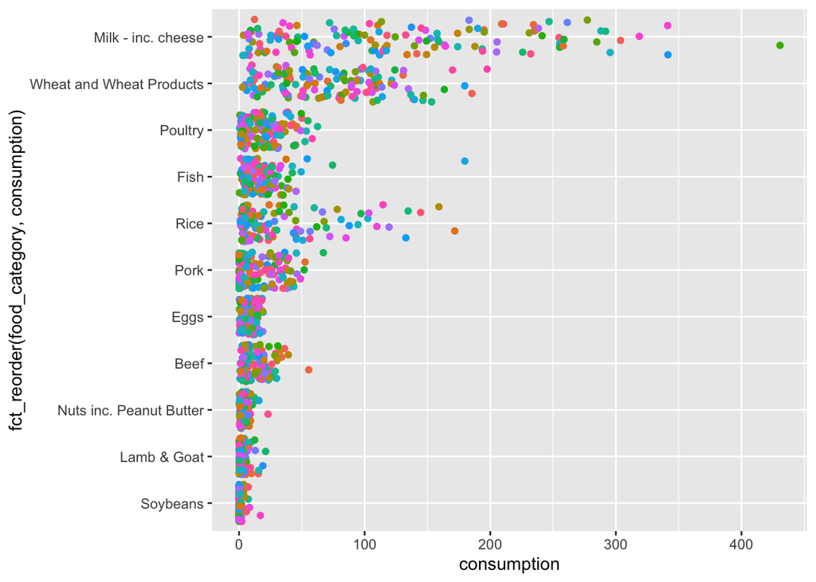

```r
clean_table %>%
  ggplot(aes(x = fct_reorder(food_category, consumption), y = consumption, color = country)) +
  geom_jitter() +
  theme(legend.position = "none") +
  coord_flip()
```